# Projekt 2 - Raport

## 2.4 Histogramy

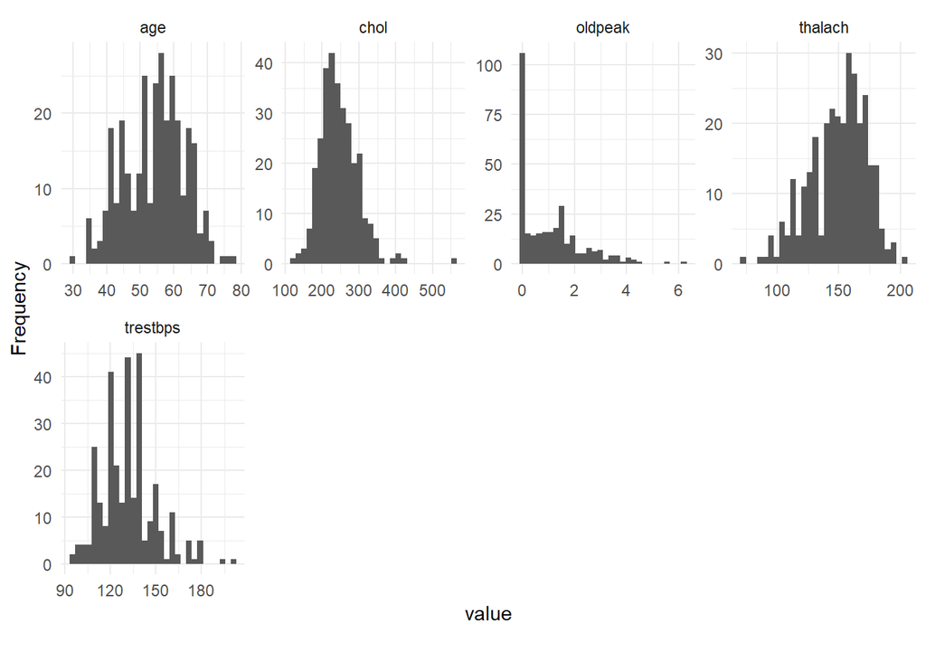

# 3 Zależności wśród danych

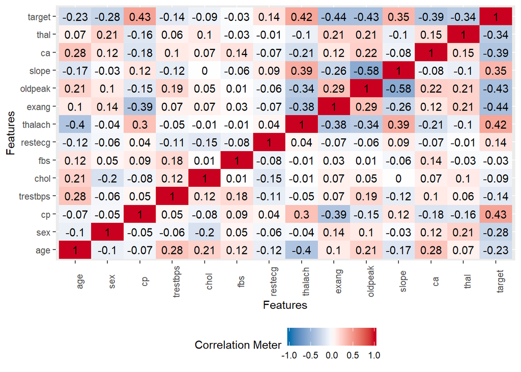

Widzimy, że występują zmienne wysoce skolerowane ze zmienną celu, im będziemy się szczególnie przyglądać.

## 3.1 Wykresy zależności

### 3.1.1 Chol od thal oraz trestbps

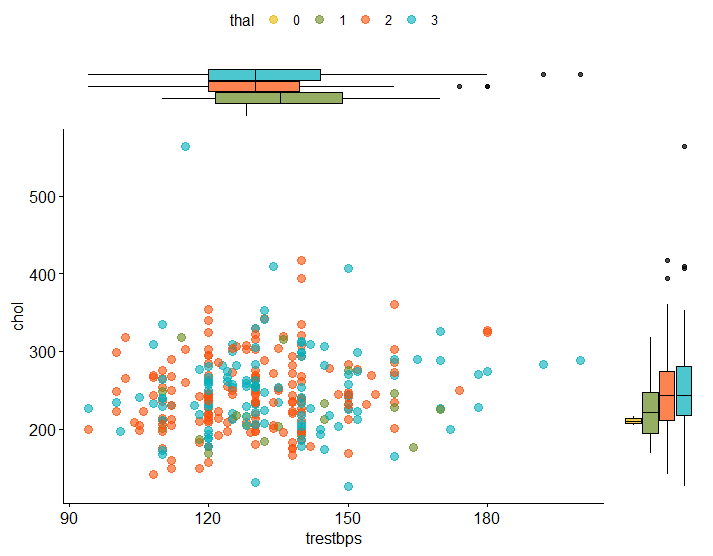

### 3.1.2 Thalach od age

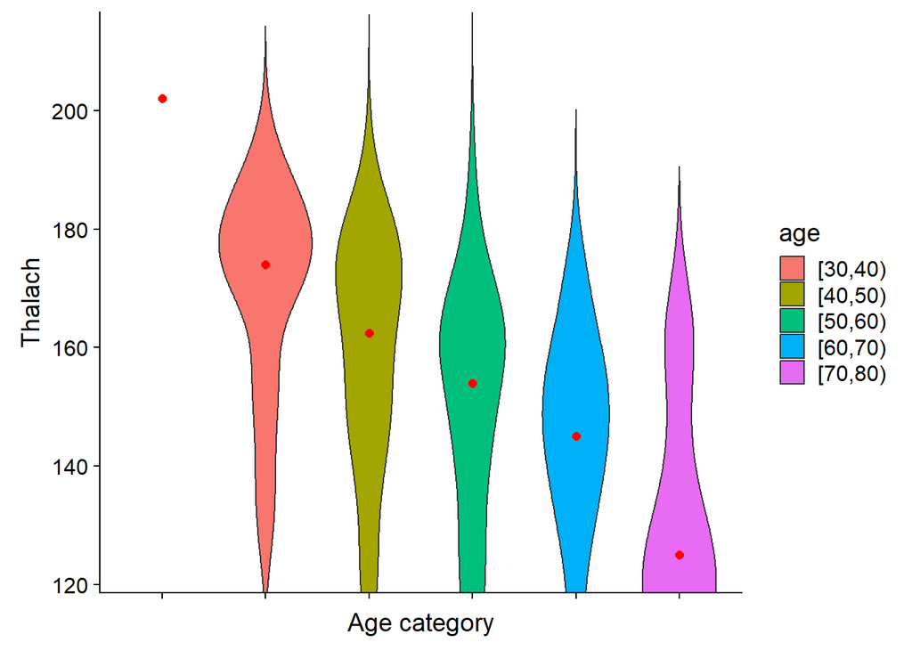

```r
datac <- read.csv('heart.csv')
datay2 <- datac
datay2[,1] <- cut(datay2[,1], breaks=c(20,30, 40, 50, 60,70,80), right = FALSE)
colnames(datay2)[1] <- 'age'
ylims <- datay2 %>%
  group_by(age) %>%
  summarise(Q1 = quantile(thalach, 1/4), Q3 = quantile(thalach, 3/4)) %>%
  ungroup() %>%
  summarise(lowQ1 = min(Q1), highQ3 = max(Q3))



plot <- ggplot(datay2, aes(age, thalach)) +
  geom_violin(aes(fill = age), trim=FALSE) + stat_summary(fun.y=median, geom="point", size=2, color="red")

plot + coord_cartesian(ylim = as.numeric(ylims)*1.05) + theme(axis.text.x = element_blank()) + xlab("Age category") + ylab("Thalach")
```

# 4 Klasteryzacja

W tym etapie przebrowadzimy analizę zbiru danych pod kątem znalezienia optymalniej liczby klastrów.

```r
library("cluster")
library("factoextra")
library("magrittr")

finalData <- data %>% scale()
Data <- data.frame(finalData)
head(Data)
```

|  | age | sex | cp | trestbps | chol | fbs | restecg | thalach | exang | oldpeak | slope | ca | thal |
| --- | --- | --- | --- | --- | --- | --- | --- | --- | --- | --- | --- | --- | --- |
| 1 | 0.9506240 | 0.6798805 | 1.96986425 | 0.76269408 | -0.25591036 | 2.3904835 | -1.0041707 | 0.01541728 | -0.69548 | 1.0855423 | -2.2708221 | -0.713249 | -2.1453238 |
| 2 | -1.9121497 | 0.6798805 | 1.00092128 | -0.09258463 | 0.07208025 | -0.4169448 | 0.8974776 | 1.63077374 | -0.69548 | 2.1190672 | -2.2708221 | -0.713249 | -0.5120748 |
| 3 | -1.4717230 | -1.4659924 | 0.03197832 | -0.09258463 | -0.81542377 | -0.4169448 | -1.0041707 | 0.97589950 | -0.69548 | 0.3103986 | 0.9747397 | -0.713249 | -0.5120748 |
| 4 | 0.1798773 | 0.6798805 | 0.03197832 | -0.66277043 | -0.19802967 | -0.4169448 | 0.8974776 | 1.23784920 | -0.69548 | -0.2063639 | 0.9747397 | -0.713249 | -0.5120748 |
| 5 | 0.2899839 | -1.4659924 | -0.93696465 | -0.66277043 | 2.07861109 | -0.4169448 | 0.8974776 | 0.58297496 | 1.43311 | -0.3786180 | 0.9747397 | -0.713249 | -0.5120748 |
| 6 | 0.2899839 | 0.6798805 | -0.93696465 | 0.47760118 | -1.04694656 | -0.4169448 | 0.8974776 | -0.07189928 | -0.69548 | -0.5508722 | -0.6480412 | -0.713249 | -2.1453238 |

## 4.1 Wybór liczby klastrów

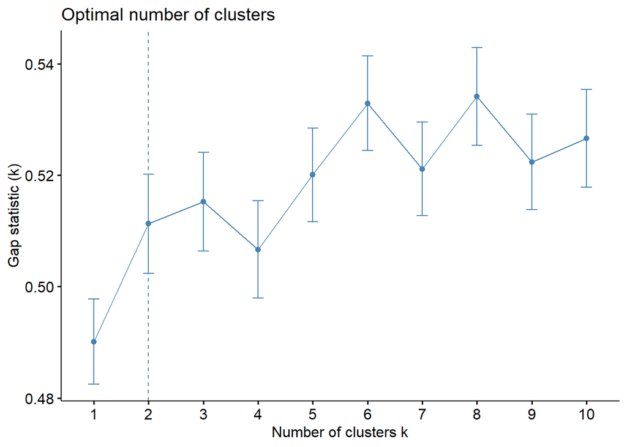

```r
fviz_nbclust(Data, kmeans, method = "gap_stat")
```

Pierwszy algorytm zaproponował podział zbioru na dwie grupy - prawdopodobnie: `chorych` i `zdrowych`. Sprawdzimy czy następny algorytm też dojdzie do takiego wniosku.

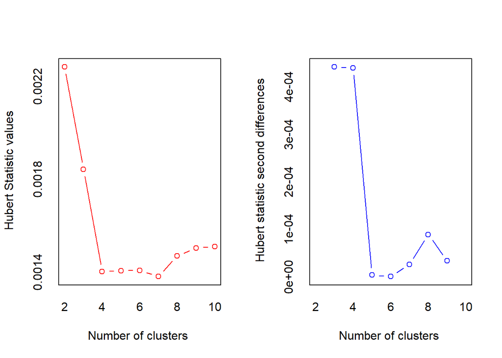

```
## *** : The Hubert index is a graphical method of determining the number of clusters.
##                 In the plot of Hubert index, we seek a significant knee that corresponds to a
##                 significant increase of the value of the measure i.e the significant peak in Hubert
##                 index second differences plot.
##
```

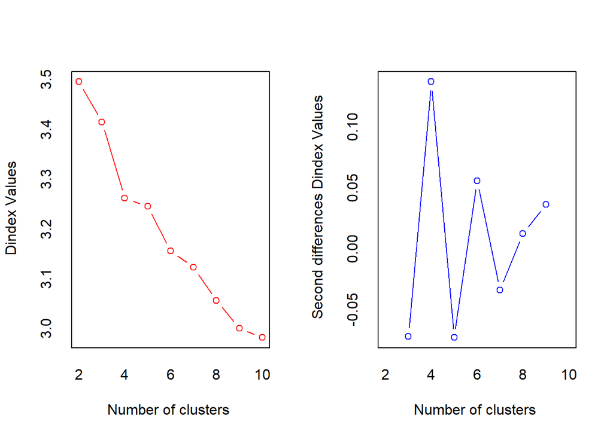

```
## *** : The D index is a graphical method of determining the number of clusters.
##                 In the plot of D index, we seek a significant knee (the significant peak in Dindex
##                 second differences plot) that corresponds to a significant increase of the value of
##                 the measure.
##
## * Among all indices:
## * 10 proposed 2 as the best number of clusters
## * 2 proposed 3 as the best number of clusters
## * 10 proposed 4 as the best number of clusters
## * 1 proposed 6 as the best number of clusters
## * 1 proposed 10 as the best number of clusters
##
##                    ***** Conclusion *****
##
## * According to the majority rule, the best number of clusters is  2
##
##
```

```r
library("NbClust")
res.nbclust <- Data %>%
  NbClust(distance = "euclidean",
          min.nc = 2, max.nc = 10,
          method = "complete", index ="all")
```

```
## Among all indices:
## ===================
## * 2 proposed  0 as the best number of clusters
## * 10 proposed  2 as the best number of clusters
## * 2 proposed  3 as the best number of clusters
## * 10 proposed  4 as the best number of clusters
## * 1 proposed  6 as the best number of clusters
## * 1 proposed  10 as the best number of clusters
##
## Conclusion
## =========================
## * According to the majority rule, the best number of clusters is  2 .
```

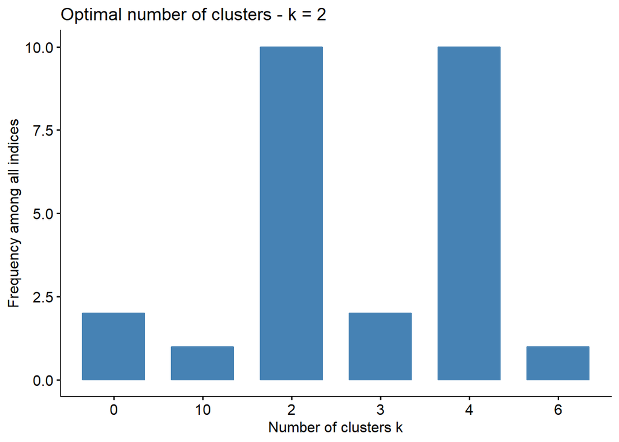

```r
fviz_nbclust(res.nbclust, ggtheme = theme_minimal())
```

Drugi algorytm uzyskał taki sam wynik dla podziału zbioru na `2` i `4` grupy. Może być to spodowane tym, że w pierwotnej ramce danych występował podział na rodzaje choroby serca. W dalszych rozważaniach będziemy przyglądać się tym dwóm podziałom.

## 4.2 PCA

Poniżej zaprezentowany jest podział na wcześniej omawiane liczności.

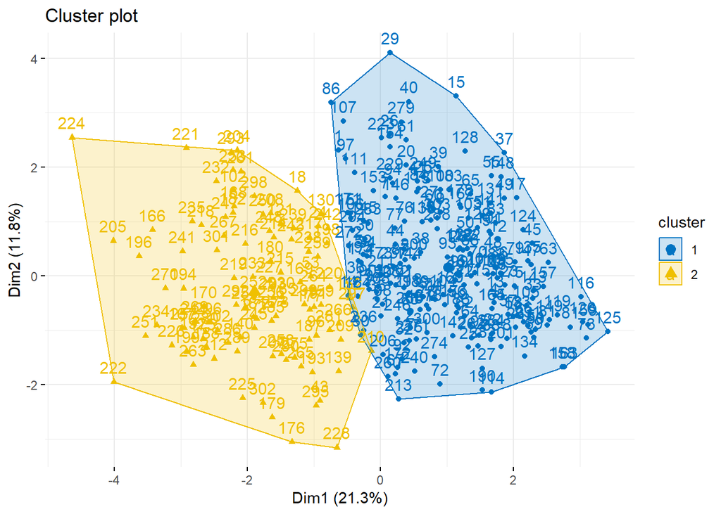

```r
km.res2 <- kmeans(Data, 2, nstart = 25)

km.res4 <- kmeans(Data, 4, nstart = 25)


fviz_cluster(km.res2, data = Data,
             ellipse.type = "convex",
             palette = "jco",
             ggtheme = theme_minimal())
```

Podział dla dwóch klastróW.

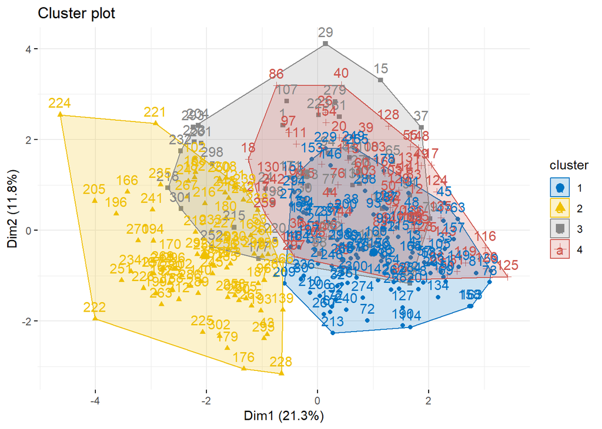

```r
fviz_cluster(km.res4, data = Data,
             ellipse.type = "convex",
             palette = "jco",
             ggtheme = theme_minimal())
```

Podział na 4 grupy.

Tutaj już redukcja wymiarów niespecjalnie nadaje się do wizualizacji podziału na grupy.

## 4.3 TSNE

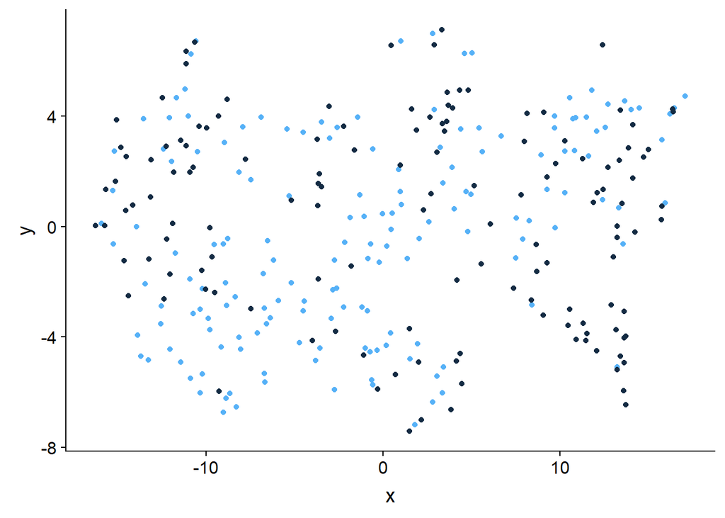

```r
library(Rtsne)
t <- read.csv('heart.csv')
datau <- unique(t)
datax <- as.matrix(datau)
set.seed(42)
tsne_out <- Rtsne(datax)
tsne_plot <- data.frame(x = tsne_out$Y[,1], y = tsne_out$Y[,2], col = datau$target)
ggplot(tsne_plot) + geom_point(aes(x=x, y=y, color=col)) + theme(legend.position = 'none')
```

Można zauważyć, że w wypadku TSNE ciężko odróżnić wizualnie klastry na wykresie.

## 4.4 Statystyki walidacji klastrów - klastrowanie hierarchiczne

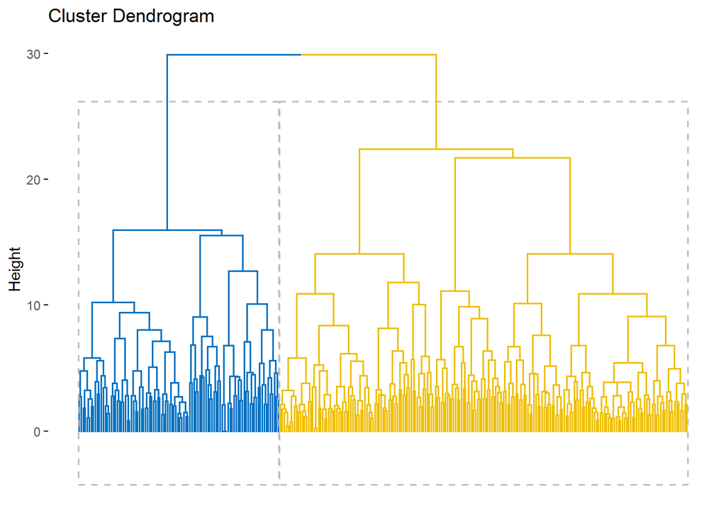

```r
res.hc <- Data %>%
  eclust("hclust", k = 2, graph = FALSE)

# Visualize with factoextra
fviz_dend(res.hc, palette = "jco",
          rect = TRUE, show_labels = FALSE)
```

Hierarchiczny podział na grupy.

### 4.4.1 2 grupy

```
##   cluster size ave.sil.width
## 1       1  203          0.15
## 2       2  100          0.10
```

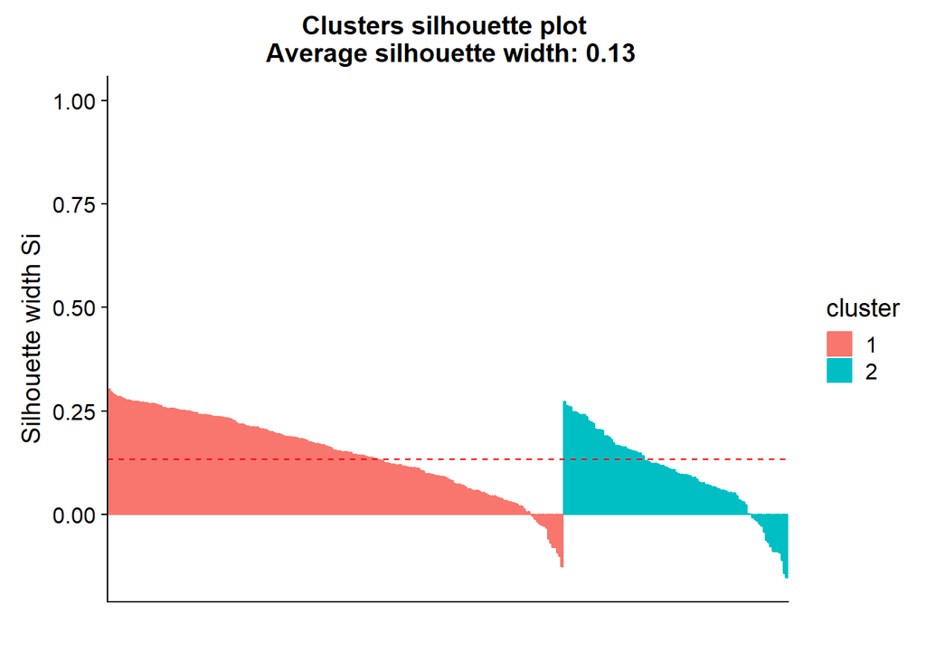

```r
fviz_silhouette(res.hc)
```

Jak widać z wykresu część obserwacji nie zostało zadowalająco przydzielona do grupy

### 4.4.2 4 grupy

```
##   cluster size ave.sil.width
## 1       1   34          0.09
## 2       2   92          0.18
## 3       3   77          0.10
## 4       4  100          0.04
```

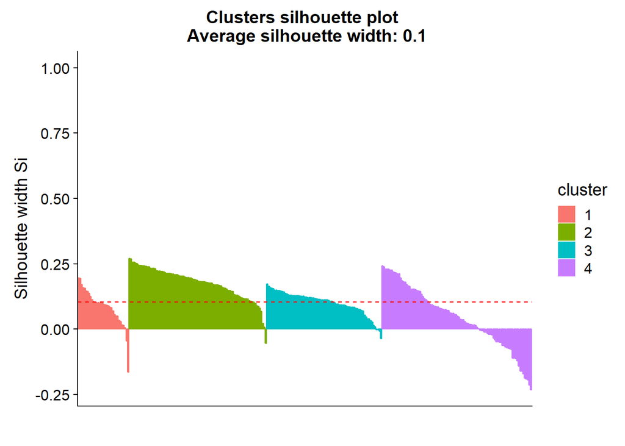

```r
res.hc4 <- Data %>%
  eclust("hclust", k = 4, graph = FALSE)
fviz_silhouette(res.hc4)
```

W podziale na 4 grupy widzimy, 3 względnie dobrze podzielone klastry i jeden, który zawiera praktycznie połowę nie do końca zbliżonych do siebie obserwacji.

## 4.5 Parallel Coordinate Plot

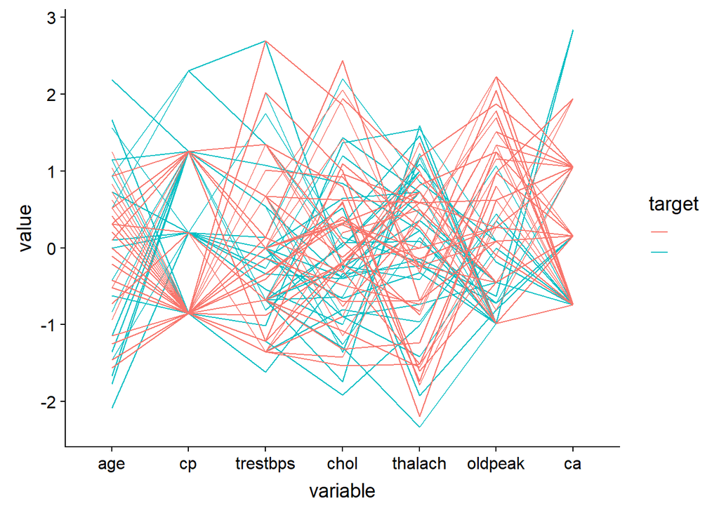

```r
library(tidyverse)
library(GGally)
library(viridis)

dataraw <- readr::read_csv("heart.csv")
datav <- dataraw[135:202,]

ggparcoord(data = datav, columns = c(1,3,4,5,8,10,12), mapping=aes(color=as.factor(target)))+
  scale_color_discrete("target",labels=levels(datav$target))
```

Na powyższym wykresie widać dobre pogrupowanie przez zmienne `cp` oraz `oldpeak`.

## 4.6 Pairwise plot

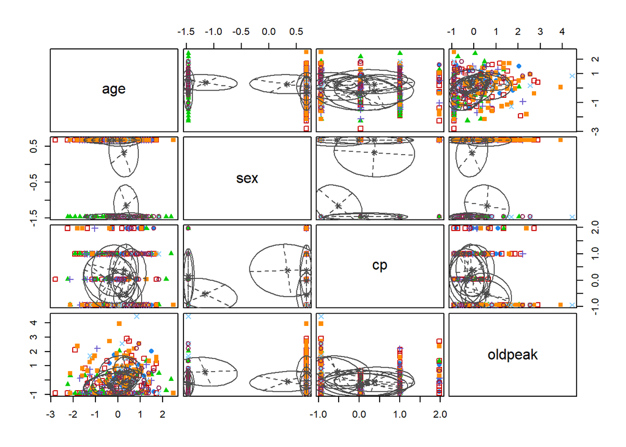

```r
library(mclust)
fit <- Mclust(Data)
plot.Mclust(fit, what='classification', dimens = c(1,2,3,10)) # plot results
```

Podsumowując można zauważyć, że problem jest złożony i nie ma jasno zarysowanych podziałów na grupy. Widać dość silne korelacje między zmiennymi. Aby odpowiednio podzielić zbiór wymagany będzie wybór odpowiedniego, algorytmu klasteryzacji.

# 5 Porównanie algorytmów klasteryzacji

Teraz postaramy się zweryfikowac, które algorytmy najlepiej pasują do naszego problemu. W związku z tym, że w zbiorze danych są odpowiedzi dotyczące choroby, wykorzystamy to w celu zweryfikowania jakości naszych finalnych modeli. Przed przystąpieniem do tej fazy projektu wyskalowaliśmy i wycentrowaliśmy nasze dane.

# 6 Internal validation

W tej sekcji będziemy analizować to jak wypadają nasze algorytmy przy użyciu trzech statystyk:

- `Dunn` - Chcemy maksymalizować indeks Dunna, który jest ilorazem minimalnej odległości pomiędzy klastrami i maksymalnej odległości pomiędzy dwoma punktami w klastrze,
- `Connectivity` - wskazuje stopień powiązania klastrów, określony przez k-najbliższych sąsiadów. Łączność odpowiada zakresowi, w jakim elementy są umieszczane w tym samym klastrze, co ich najbliżsi sąsiedzi w przestrzeni danych. Łączność ma wartość od 0 do nieskończoności i powinna być zminimalizowana.
- `Slilhouette` - Liczymy średnią odległość pomiędzy ustalonym punktem, a innymi punktami w tym klastrze. Liczymy średnią odległość pomiędzy ustalonym punktem, a innymi punktami w najbliższym sąsiednim klastrze. Liczymy iloraz różnicy tych odległości i większej z nich.

## 6.1 Porównanie podstawowych modeli

```r
heart <- read.csv('heart.csv')
data <- select(heart, - target)
data <- na.omit(data)
data <- center_scale(data, mean_center = T, sd_scale = T)
```

### 6.1.1 Opis modeli

Zdecydowaliśmy się rozpatrzeć pare modeli. Wybraliśmy modele, które uznaliśmy za ciekawe albo takie, które są inne.

Rozpatrujemy takie modele jak:

- `hierarchical` - algorytm hierarchiczny,
- `kmeans` - k-średnich,
- `diana` - dzielące hierarchiczne klastrowanie,
- `GMM` - estymujemy parametry rozkładu gausowskiego i na ich podstawie liczymy prawdopodobieństwo przynależności do każdego klastra,
- `model` - inna implementacja GMM,
- `sota` - algorytm samo-organizującego się drzewa,
- `pam` - k-medoidów,
- `clara` - k-medoidów dla dużej ilości danych,
- `DBSCAN` - nieparametryczny algorytm oparty na gęstości,
- `Fanny` - ‘miękkie’, jeden punkt może należeć do wielu klastrów.

### 6.1.2 Wyniki

Ze względu na póżniejszą walidację zewnetrzną w tej części skupimy się na wynikach uzyskanych dla podziału na 2 klastry.

```r
intern <- clValid(data, nClust = 2:7, clMethods=c("hierarchical","kmeans",'diana','model','sota','clara',"pam"), validation = 'internal', verbose = F)
kable_styling(kable(summary(intern)))
```

```
##
## Clustering Methods:
##  hierarchical kmeans diana model sota clara pam
##
## Cluster sizes:
##  2 3 4 5 6 7
##
## Validation Measures:
##                                   2        3        4        5        6        7
##
## hierarchical Connectivity    2.9290   9.0298   9.0298  30.5310  37.6956  39.1456
##              Dunn            0.4532   0.3878   0.3878   0.3483   0.3483   0.3483
##              Silhouette      0.3533   0.2769   0.2407   0.1849   0.1468   0.1300
## kmeans       Connectivity   46.0353 134.3933 154.6020 171.0159 200.4730 219.3321
##              Dunn            0.2179   0.1300   0.1744   0.1744   0.1148   0.1731
##              Silhouette      0.0948   0.1162   0.1176   0.1226   0.1174   0.1192
## diana        Connectivity   48.8595  61.2726  71.9655 115.7690 132.1139 133.2179
##              Dunn            0.1359   0.1462   0.1474   0.1539   0.1580   0.1663
##              Silhouette      0.0960   0.0810   0.0633   0.1093   0.1074   0.1078
## model        Connectivity  133.5024 117.3496  93.9115 174.1917 172.8631 226.0667
##              Dunn            0.0948   0.1645   0.2120   0.1298   0.2027   0.1469
##              Silhouette      0.0961   0.0128   0.0992   0.0147   0.0550   0.0207
## sota         Connectivity   84.0167 146.1583 165.9615 168.1405 169.3627 169.4877
##              Dunn            0.1670   0.1670   0.1670   0.1670   0.1670   0.1670
##              Silhouette      0.1630   0.1380   0.1044   0.1048   0.0956   0.0899
## clara        Connectivity   89.6460 199.4730 239.6393 217.9623 248.3032 275.7877
##              Dunn            0.1670   0.1460   0.1241   0.1124   0.1244   0.0920
##              Silhouette      0.1630   0.1027   0.0973   0.0654   0.0690   0.0561
## pam          Connectivity  108.7321 173.5611 211.6313 197.2222 226.9956 258.8361
##              Dunn            0.1468   0.1583   0.1196   0.1196   0.1342   0.1244
##              Silhouette      0.1591   0.1066   0.1016   0.1079   0.1024   0.0873
##
## Optimal Scores:
##
##              Score  Method       Clusters
## Connectivity 2.9290 hierarchical 2
## Dunn         0.4532 hierarchical 2
## Silhouette   0.3533 hierarchical 2
```

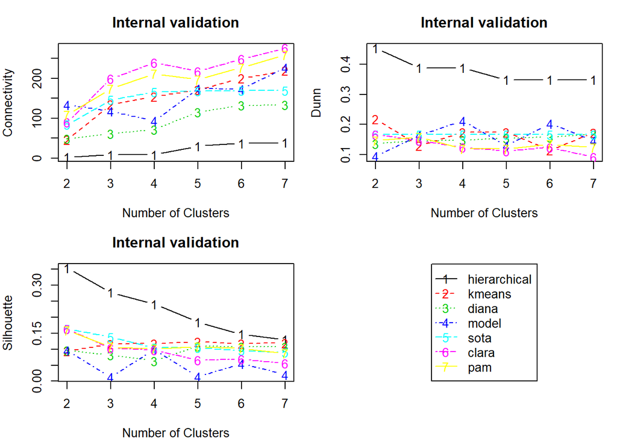

```r
op <- par(no.readonly=TRUE)
par(mfrow=c(2,2),mar=c(4,4,3,1))
plot(intern, legend=FALSE)
plot(nClusters(intern),measures(intern,"Dunn")[,,1],type="n",axes=F,xlab="",ylab="")
legend("center", clusterMethods(intern), col=1:7, lty=1:7, pch=paste(1:7))
```

Najlepiej ze wszystkich algorytmów poradził sobie model `hierarchiczny` - uzyskał on najlepsze wyniki względem każdej statystyki dla interesującej nas liczby klastrów - 2. Całkiem dobrze poradził sobie także `kmeans` uzyskując drugi wynik w teście Dunn i Connectivity, zadowalające wyniki uzyskała też `clara` zajmując druge miejsce pod względem `Silhouette Width`. Widać też, że większość algorytmóW wypadła najlepiej dzieląc dane na dwa klastry.

## 6.2 Dodatkowe algorytmy

### 6.2.1 DBSCAN

Na początku wybierzemy optymalną wartość dla parametru eps powinna ona znajdować się na kolanie na poniższym wykresie.

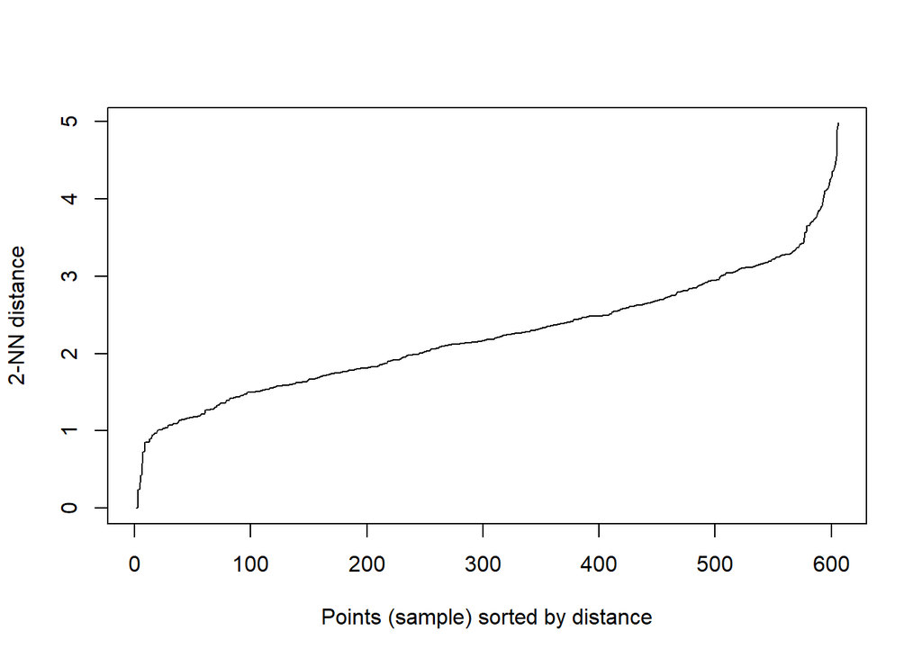

```r
library(dbscan)
dbscan::kNNdistplot(data, k=2)
```

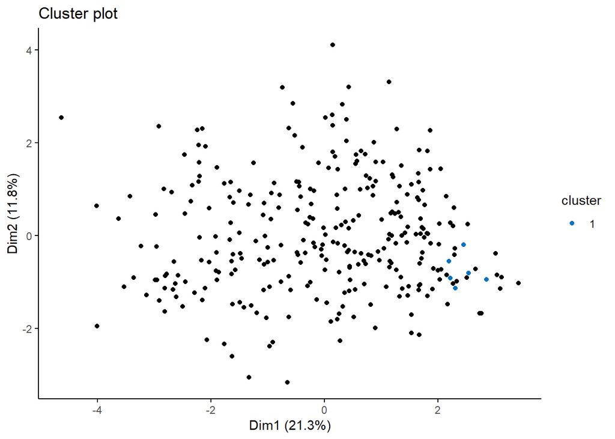

```r
library(fpc)

db <- fpc::dbscan(data, eps = 1.2, MinPts = 5)

fviz_cluster(db, data = data, stand = FALSE,
             ellipse = FALSE, show.clust.cent = FALSE,
             geom = "point",palette = "jco", ggtheme = theme_classic())
```

Tym razem algorytm podzielił zbiór na jeden klaster i wartości odstające, wskazuje to na inny sposób działania w porówaniu do pozostałych metod.

### 6.2.2 GMM

GMM to algorytm z rodzaju EM (Expectation – Maximalization), w któym zakłada się, że zbiór danych można opisać mieszaniną rozkładów normalnych. Algorytm GMM wymaga podania a priori liczby klastrów:

```r
dat = center_scale(data, mean_center = T, sd_scale = T)

gmm = GMM(data, 2, dist_mode = "maha_dist", seed_mode = "random_subset", km_iter = 10,
          em_iter = 10, verbose = F)

pr = predict_GMM(dat, gmm$centroids, gmm$covariance_matrices, gmm$weights)
```

Funkcja Optimal_Clusters_GMM, może być użyta do wyznaczenie optymalnej liczności klastróW. W tym przypadku do oceny wybraliśmy kryterium Bayesian information.

```r
opt_gmm = Optimal_Clusters_GMM(dat, max_clusters = 10, criterion = "BIC",

                               dist_mode = "maha_dist", seed_mode = "random_subset",

                               km_iter = 10, em_iter = 10, var_floor = 1e-10,

                               plot_data = T)
```

[output not shown]

### 6.2.3 Fanny

```r
intern <- clValid(data, nClust = 2:3, clMethods=c("fanny"), validation = 'internal')
summary(intern)
```

```
##
## Clustering Methods:
##  fanny
##
## Cluster sizes:
##  2 3
##
## Validation Measures:
##                            2        3
##
## fanny Connectivity  117.6413 238.4310
##       Dunn            0.1236   0.0726
##       Silhouette      0.1498  -0.0183
##
## Optimal Scores:
##
##              Score    Method Clusters
## Connectivity 117.6413 fanny  2
## Dunn           0.1236 fanny  2
## Silhouette     0.1498 fanny  2
```

# 7 External Validation

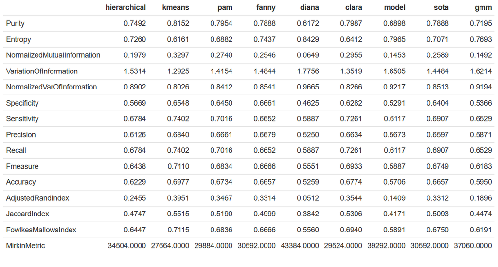

## 7.1 Wykres Rand-index

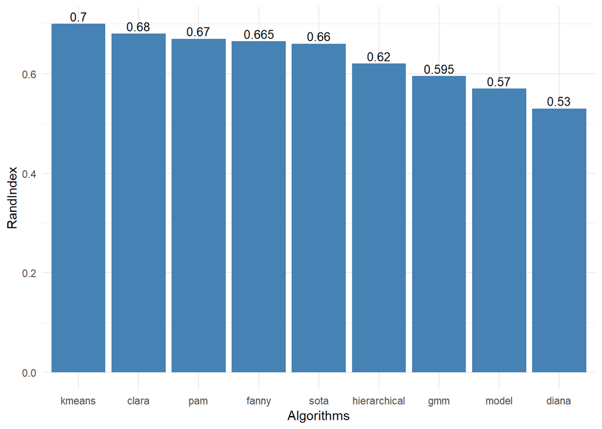

```r
Algorithms <- c('hierarchical','kmeans','pam','fanny','diana','clara','model','sota','gmm')
RandIndex <- c(0.62,0.7,0.67,0.665,0.53,0.68,0.57,0.66,0.595) #rank index

Algorithms <- as.data.frame(Algorithms)
df <- cbind(Algorithms,RandIndex )

ggplot(data=df, aes(x=reorder(Algorithms, -RandIndex), y=RandIndex )) +
  geom_bar(stat="identity", fill="steelblue")+
  geom_text(aes(label=RandIndex ), vjust=-0.3, size=3.5)+
  theme_minimal() + xlab("Algorithms")
```

# 8 Internal a External - wnioski

Porównując oba sbosoby walidacji klastryzacji widzimy, że niektóre algorytmy osiągnęły wysokie wyniki w obu testach, aczkolwiek np. zwycięzca walidacji wewnętrzej bardzo słabo poradził sobie jeśli chodzi o porównanie z prawdziwymi etykietami. Jest to prawdopodobnie spowodowane charakterem danych, które nie są proste do podziału.

# 9 Porównanie najciekawszych

## 9.1 Oryginalny podział

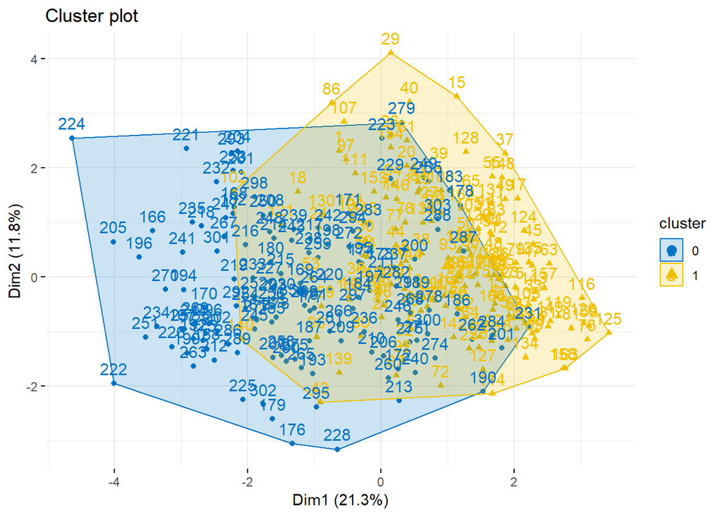

```r
hc0  <- list(data = data, cluster = heart$target)

fviz_cluster(hc0, data = Data,
             ellipse.type = "convex",
             palette = "jco",
             ggtheme = theme_minimal())
```

PCA nie do końca wyjaśnia podział na klastry, choć widać sporoą zależność względem DIM1.

## 9.2 Kmeans

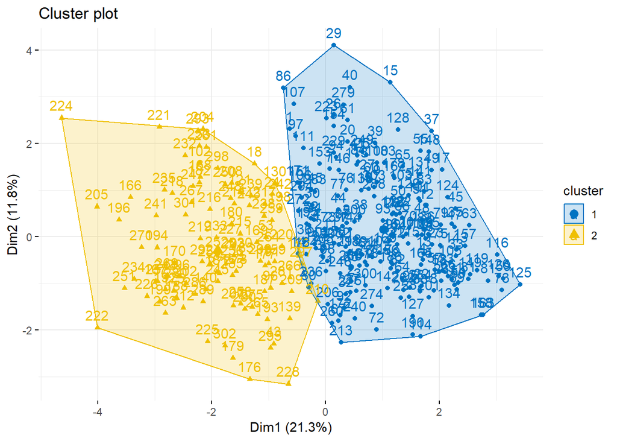

```r
hc <- data %>% eclust("kmeans", k = 2, graph = FALSE)

fviz_cluster(hc, data = Data,
             ellipse.type = "convex",
             palette = "jco",
             ggtheme = theme_minimal())
```

## 9.3 Hierarchical

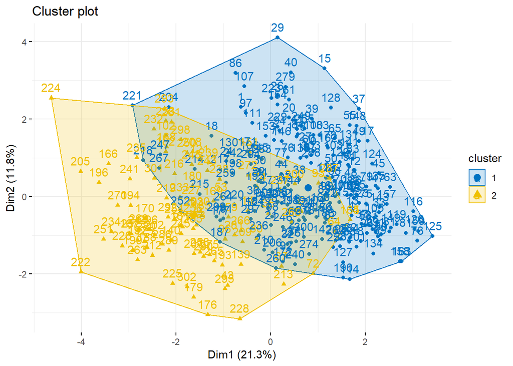

```r
hc2 <- data %>% eclust("hclust", k = 2, graph = FALSE)

fviz_cluster(hc2, data = Data,
             ellipse.type = "convex",
             palette = "jco",
             ggtheme = theme_minimal())
```

## 9.4 Clara

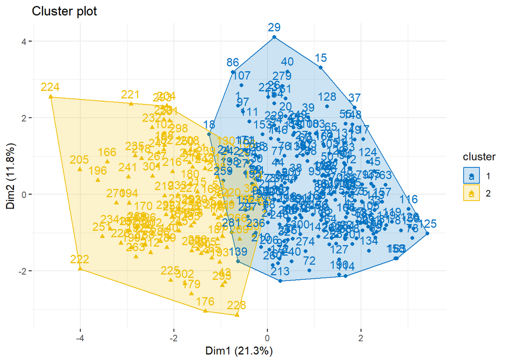

```r
hc3 <- eclust(data, 'clara', k = 2, graph=FALSE)
fviz_cluster(hc3, data = Data,
             ellipse.type = "convex",
             palette = "jco",
             ggtheme = theme_minimal())
```

# 10 Podsumowanie

Podsumowując powyższe testy wydajności różnych algorytmów klasteryzacji ciężko wybrać pojedyńczego zwycięzcę, jednak `kmeans`, oraz `hierarchical`, `clara` wydają się najlepiej sobie radzić z problemem. Klasteryzacja hierarchiczna zdecydowania wygrywa pod względem wewnętrznych statystyk porównawczych, więc zapewne bez wiedzy o prawdziwych etykietach to właśnie ona by była naszym wyborem. Biorąc pod uwagę róWnież zewnętrzne statystyki, czyli porównując z *Gold Standardem* bardziej skłaniamy się do wyboru algorytmu `kmeans` oraz `clara`.